# **Machine** **Learning** **Project**

# Introduction

The dataset consists of a large set of data points provided over 64 financial indicators. These financial indicators serve as the feature set for our machine learning problem and consist of numerical data. The eventual goal of the machine learning model is to predict whether the company will go bankrupt or not, therefore, it is a binary classification problem with its prediction values as 1 = Bankrupt and 0 = Not Bankrupt. The project also covers various scenarios one comes accros when dealing with data in the real world such as missing data, haphazard attribute names, irregular attribute values, co-related features and unbalanced classes. We apply various preprocessing methods to address these data issues.

Date 28/Nov/2019.

```python
import pandas as pd
import seaborn as sns
import matplotlib.pyplot as plt
from sklearn.neural_network import MLPClassifier
from sklearn.neighbors import KNeighborsClassifier
from sklearn.svm import SVC
from sklearn.linear_model import LogisticRegression
from sklearn.tree import DecisionTreeClassifier
from sklearn.ensemble import RandomForestClassifier, AdaBoostClassifier
from sklearn.naive_bayes import GaussianNB
from sklearn.discriminant_analysis import QuadraticDiscriminantAnalysis
from sklearn.pipeline import make_pipeline
from sklearn.preprocessing import StandardScaler
from sklearn.metrics import roc_curve
from sklearn.metrics import roc_auc_score
from sklearn.model_selection import train_test_split
import numpy as np
from sklearn.impute import SimpleImputer
from sklearn.metrics import f1_score
from sklearn.utils import resample
from sklearn.metrics import confusion_matrix
from sklearn.metrics import precision_score
from sklearn.metrics import recall_score
```

# Data Analysis and Visualization

We start by performing data analysis on the dataset. There are 64 feautres and 10503 instances. The label is categorical in nature. Hence, we decide to use classification algorithms for prediction. Here, we observe that the classes are unbalanced. Class corresponding to non-bankruptcy has 10008 instances and class corresponding to bankruptcy has 495 instances. The same is shown by Pie Chart.

As the first step, we import all the required libraries followed by the data from the CSV files into the Jupyter notebook. In the next step, we use the replace method to deal with irregular label values such as b'0 and b'1. We then proceed with Data Visualization. We have plotted the Pair Plot.

To get a glance at the data we plotted some points, however we could not do it over all the features so we show only the first 10 features.

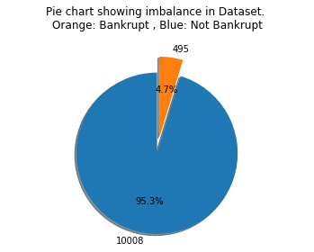

```
       X1 net profit / total assets  X2 total liabilities / total assets  \
count                      10503.00                             10503.00
mean                           0.05                                 0.62
std                            0.65                                 6.43
min                          -17.69                                 0.00
25%                            0.00                                 0.25
50%                            0.04                                 0.46
75%                            0.12                                 0.69
max                           52.65                               480.73

       X3 working capital / total assets  \
count                           10503.00
mean                                0.10
std                                 6.42
min                              -479.73
25%                                 0.02
50%                                 0.20
75%                                 0.42
max                                17.71

       X4 current assets / short-term liabilities  \
count                                    10485.00
mean                                         9.98
std                                        523.69
min                                          0.00
25%                                          1.04
50%                                          1.61
75%                                          2.96
max                                      53433.00

       X5 [(cash + short-term securities + receivables - short-term liabilities) / (operating expenses - depreciation)] * 365  \
count                                           10478.00
mean                                            -1347.66
std                                            118580.57
min                                         -11903000.00
25%                                               -52.07
50%                                                 1.58
75%                                                56.08
max                                            685440.00

```

[output cut: 76 more lines]

```
50%                                        70.66
75%                                       118.22
max                                   1073500.00

       X63 sales / short-term liabilities  X64 sales / fixed assets     class
count                            10485.00                  10275.00  10503.00
mean                                 9.10                     35.77      0.05
std                                 31.42                    428.30      0.21
min                                 -0.00                     -0.00      0.00
25%                                  3.06                      2.02      0.00
50%                                  5.14                      4.06      0.00
75%                                  8.88                      9.68      0.00
max                               1974.50                  21499.00      1.00

[8 rows x 65 columns]
```

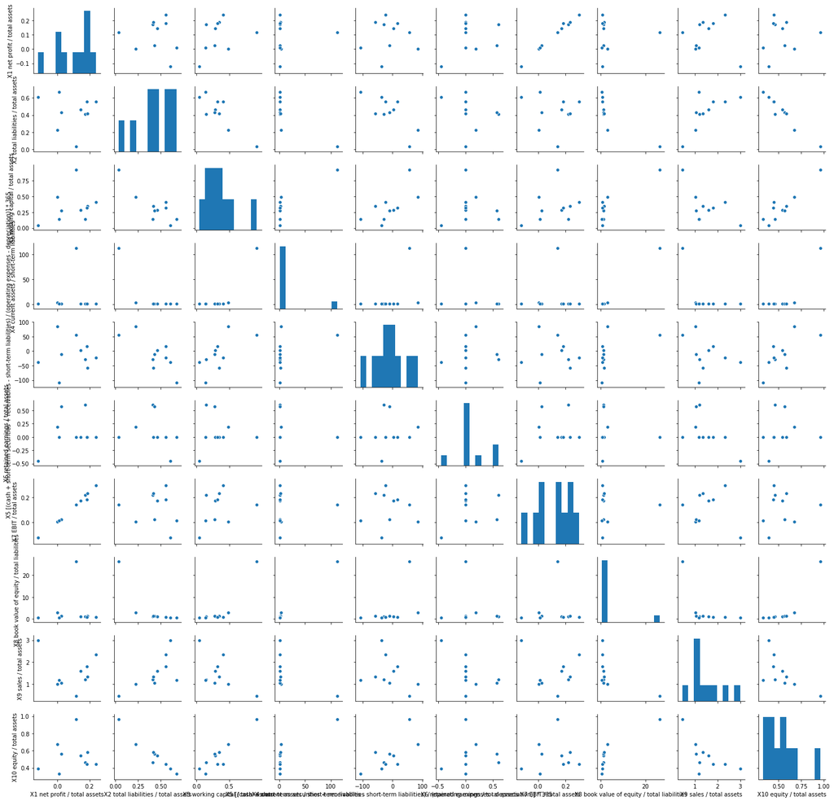

```python
d =pd.read_csv("bankruptcy.csv")
cols = pd.read_csv("ColumnNames.csv")
d.columns = cols.columns
label_column = "class"
d[label_column].replace("b'0'", 0b0, inplace=True)
d[label_column].replace("b'1'", 0b1, inplace=True)

feature_columns = [c for c in d.columns if c != label_column]
X = d[feature_columns].values
y = d[label_column].values

#Pie chart
x = d['class'].value_counts()
labels = x
sizes = x
explode = (0, 0.2)
fig1, ax1 = plt.subplots()
ax1.pie(sizes, explode=explode, labels=labels, autopct='%1.1f%%',
        shadow=True, startangle=90)
ax1.axis('equal')
plt.title("Pie chart showing imbalance in Dataset. \nOrange: Bankrupt , Blue: Not Bankrupt\n")
plt.show()

# Showing only partil data
sns.pairplot(d.iloc[0:10, 0:10])
print(d.describe().round(2))
```

# Data Preprocessing

```python
imp = SimpleImputer(missing_values=np.nan, strategy='most_frequent')
imp.fit(X)
X = imp.transform(X)

from sklearn.svm import LinearSVC
from sklearn.feature_selection import SelectFromModel

print("Original feature size")
print("X.shape", X.shape)

lsvc = LinearSVC(penalty="l1", dual=False, C=0.1, max_iter=1000000).fit(X, y)
model = SelectFromModel(lsvc, prefit=True)
X = model.transform(X) # select only new features
print("Feature size after regularization")
print("X.shape", X.shape)
```

```
Original feature size
X.shape (10503, 64)
Feature size after regularization
X.shape (10503, 42)
```

With L1 or Lasso regularatizations, many of the coeffiecients are zero. Since our goal is to reduce the dimensionality of the data, this method can be used along with feature selection. In particular, sparse estimators useful for this purpose are Linear Model Lasso for regression, and Support Vector Classifier for classification. [2]

The heat map shows only the selected features and their correlation.

```python
#Plot heat map
feature_idx = model.get_support()
feature_cols = d[feature_columns]
feature_name = feature_cols.columns[feature_idx]
plt.figure(figsize=(100,100))
g=sns.heatmap(d[feature_name].corr(),annot=True,cmap="RdYlGn")
```

[figure not shown]

# Hyperparameters Tuning

In this section, the Hyperparameters are tuned for the 10 models that are picked. The most relevant and commonly specified Hyperparameters values are chosen and plugged in the models in order to achieve good predicitions. The scikit-learn library example [3] was referred for selecting the parameters for each model.

```python
names = ["Logistic Regession with Lasso", "Logistic Regression with Ridge", "Logistic Regression Elastic Net", "KNeighbors Classifier", "Linear SVM", "RBF SVM",
         "Decision Tree", "Neural Net", "AdaBoost",
         "Naive Bayes"]

classifiers = [LogisticRegression(C=0.5, penalty='l1', tol=0.01, solver='saga'),
    LogisticRegression(C=0.5, penalty='l2', tol=0.01, solver='saga'),
    LogisticRegression(C=0.5, penalty='elasticnet', solver='saga', l1_ratio=0.5, tol=0.01),
    KNeighborsClassifier(3),
    SVC(kernel="linear", C=0.025, class_weight='balanced', probability=True),
    SVC(gamma=2, C=1, probability=True, class_weight='balanced'),
    DecisionTreeClassifier(max_depth=5, class_weight='balanced'),
    MLPClassifier(alpha=1, max_iter=1000),
    AdaBoostClassifier(),
    GaussianNB()]
```

# Training models and Comparing Metrics

We split the model into train set and test set. We take 80% of the instances to train the model and keep the remaining 20% to test it. We are training and testing on 10 different classifiers namely Logistic Regression with Lasso, Logistic Regression with Ridge, Logistic Regression with Elastic Net, KNeighbors Classifier, Linear SVM, RBF SVM, Decision Tree, Neural Net, AdaBoost and Naive Bayes, in order to select the best fit for the dataset. After training and testing, ROC AUC and F1 score are calculated. Based on these metrics we choose the best model for the given dataset.

When we have unbalanced classes, we would only have a high presicion value by predicting the mayority class. There are several strategies to handle unbalanced classes. One is penalizing the model when it predicts incorrectly in the minority class. This was done by adding class_weight='balanced'. One other aproach is resampling the minority class so it is balanced, or downsampling the mayority class. After we chose to resample the minority class, some models stop predicting only the mayority class. [4]

```
mayority class size 344086
minority class size 17200
upsample size (8002, 43)
X_train original size (8402, 42)
x train size (16004, 42)
y_train_size (16004,)
Training  Logistic Regession with Lasso...
Logistic Regession with Lasso ROC_AUC_SCORE : 0.7227
F1 score:  0.1576
Recall:  0.6421
Precision:  0.0898
------------------------------------------------------
Training  Logistic Regression with Ridge...
Logistic Regression with Ridge ROC_AUC_SCORE : 0.7233
F1 score:  0.1576
Recall:  0.6421
Precision:  0.0898
------------------------------------------------------
Training  Logistic Regression Elastic Net...
Logistic Regression Elastic Net ROC_AUC_SCORE : 0.7232
F1 score:  0.1576
Recall:  0.6421
Precision:  0.0898
------------------------------------------------------
Training  KNeighbors Classifier...
KNeighbors Classifier ROC_AUC_SCORE : 0.5643
F1 score:  0.1232
Recall:  0.1789
Precision:  0.0939
------------------------------------------------------
Training  Linear SVM...
Linear SVM ROC_AUC_SCORE : 0.746
F1 score:  0.1734
Recall:  0.7053
Precision:  0.0988
------------------------------------------------------
Training  RBF SVM...
RBF SVM ROC_AUC_SCORE : 0.6885
F1 score:  0.1691
Recall:  0.4947
```

[output cut: 11 more lines]

```
Recall:  0.7158
Precision:  0.0908
------------------------------------------------------
Training  AdaBoost...
AdaBoost ROC_AUC_SCORE : 0.82
F1 score:  0.2147
Recall:  0.7053
Precision:  0.1267
------------------------------------------------------
Training  Naive Bayes...
Naive Bayes ROC_AUC_SCORE : 0.4989
F1 score:  0.0849
Recall:  0.9474
Precision:  0.0445
------------------------------------------------------
```

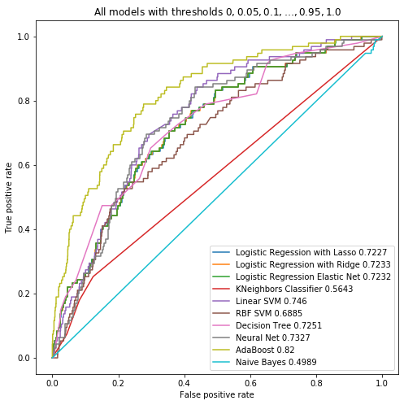

```python
scores = []

#data split
# Separate majority and minority classes
X_train, X_test, y_train, y_test = train_test_split(X, y, test_size=0.20, random_state=0)

y_train = y_train.reshape(len(y_train),1)
data = np.concatenate((X_train, y_train), axis=1)
df_minority = data[data[:,-1] == 1]
df_mayority = data[data[:,-1] == 0]

print("mayority class size", df_mayority.size)
print("minority class size", df_minority.size)

df_minority_upsampled = resample(df_minority,
                                 replace=True,     # sample with replacement
                                 n_samples=np.shape(df_mayority)[0],    # to match majority class
                                 random_state=123) # reproducible results

print("upsample size", df_minority_upsampled.shape)
print("X_train original size", X_train.shape)
X_train = np.concatenate((df_mayority[:,0:-1], df_minority_upsampled[:,0:-1]))
y_train = np.concatenate((df_mayority[:, -1], df_minority_upsampled[:,-1]))

print("x train size", X_train.shape)
print("y_train_size", y_train.shape)

fig, ax = plt.subplots(figsize=(8, 8))
for name, clf in zip(names, classifiers):
    print("Training " , name + '...')
    model = make_pipeline(
        StandardScaler(),
        clf).fit(X_train, y_train)
    fprs, tprs, thresholds = roc_curve(y_test, model.predict_proba(X_test)[:, 1])
    roc_score = round(roc_auc_score(y_test, model.predict_proba(X_test)[:, 1]),4)
    ax.plot(fprs, tprs, label=name + " " + str(roc_score))
    ax.set_xlabel('False positive rate')
    ax.set_ylabel('True positive rate')
    ax.set_title(r"All models with thresholds $0, 0.05, 0.1, \ldots, 0.95, 1.0$");
    ax.legend()
    print(name + " ROC_AUC_SCORE :", roc_score)
    print("F1 score: ", round(f1_score(y_test, model.predict(X_test)),4))
    print("Recall: ", round(recall_score(y_test, model.predict(X_test)),4))
    print("Precision: ", round(precision_score(y_test, model.predict(X_test)),4))
    print("------------------------------------------------------")
```

# Model Selection

```python
names = ["Decision Tree", "AdaBoost"]

classifiers = [
    DecisionTreeClassifier(max_depth=5),
    AdaBoostClassifier()]

scores = ['f1' , 'roc_auc', 'f1_micro']

#data split

from sklearn.model_selection import cross_val_score
from sklearn.model_selection import KFold

kfold = KFold(n_splits = 10, shuffle = True, random_state = 3)
for name, clf in zip(names, classifiers):
    print("Training " , name + '...')
    for score in scores:
        Model_scores = cross_val_score(clf, X_train, y_train, scoring = score, cv = kfold)
        avg = round(np.mean(Model_scores),4)
        print("Scores: ", score , avg)
    print('----------------------------------------------------')
```

[output not shown]

The best model is Adaboost. We evaulate the performance of the the winner model over the test set.

```python
model = make_pipeline(
    StandardScaler(),
    AdaBoostClassifier()
).fit(X_train, y_train)

print("Recall: ", round(recall_score(y_test, model.predict(X_test)),4))
print("Precision: ", round(precision_score(y_test, model.predict(X_test)),4))
print("F1 score: ", round(f1_score(y_test, model.predict(X_test)),4))
print("ROC-AUC: ", round(roc_auc_score(y_test, model.predict_proba(X_test)[:, 1]),4))
matrix = confusion_matrix(y_test, model.predict(X_test))
print(matrix)
```

[output not shown]

# Retrain the model with all data

In our final step, we train on the entire dataset with the winner model - Adaboost. This model is ready for production after re-training.

```python
model = make_pipeline(
    StandardScaler(),
    AdaBoostClassifier()
).fit(X,y)
```

# Conclusion

## AdaBoost:

F1 Score: 0.20

ROC Score: 0.81

Our model has a precision score of 12% to predict whether a company will go bankrupt or not. While this may not be a high value, it is representative of real-world situations, which is better than having an unnaturally high precision value by just predicting the majority class and ignoring the minority class.

## **References**

**[1] Scikit Learn Impute**

https://scikit-learn.org/stable/modules/impute.html

**[2] Scikit Learn Feature Selection**

https://scikit-learn.org/stable/modules/feature_selection.html

**[3] Scikit Learn Classifier Comparison**

https://scikit-learn.org/stable/auto_examples/classification/plot_classifier_comparison.html

**[4] Imbalanced Classes**

https://elitedatascience.com/imbalanced-classes